# Senior Software Engineer Test

> Your Mission, should you choose to accept it, is to design and implement an efficient algorithm for detecting Sleep Apnoea events in prerecorded audio files.

## Problem Domain

> **DISCLAIMER**: *The problem, although inspired in a real world problem, is completly made up just for this test's sake and any similarity with real world systems for detecting apnoeas is coincidental*

[Sleep Apnoea](https://en.wikipedia.org/wiki/Sleep_apnea) is a sleep disorder characterized by pauses in breathing or instances of shallow or infrequent breathing during sleep. Each **pause** in breathing, called an **apnea**, can last for several **seconds** to several **minutes**, and may occur an arbitrary number of times during sleep.

Acurable, using [Acupebble](http://www.acupebble.com/) based technologies, is able to capture the acoustic signals produced by the body, like breathing, and extract useful information for diagnosing several health conditions. The acousting signals are typically generated, transmited and stored on files using [Uncompressed Audio Formats](https://en.wikipedia.org/wiki/Audio_file_format#Uncompressed_audio_format). Acurable's services process, potentially in real-time, those files extracting features or information (variety of physiological and disease related parameters, such as breathing rate, lung volumes, etc) which are then used to identify particular events and potentially diagnose health conditions.

As an example, "*normal*" breathing during sleep may sound and look like this:

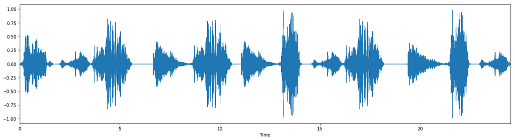

[interactive chart not shown]

In the above example, you may hear (and maybe observe in the graph), that during sleep the breathing may involve the production of a variaty of sonorous breath sounds like: crackles, discontinuous sounds, continuous low-pitched sounds, stridor continuous sounds, sibilant or even musical sounds. All of those may be normal sounds or, at least, not related to serious health conditions.

In our case, we are particularly interested in the prolonged absence of sound, which indicates pauses in breathing and, if severe, correlated with serious health concerns. Notice that during normal breathing there are actually pauses which are considered normal. As shown above, breathing is a rythmic pattern consisting of (maybe sonorous) breathe-ins and breathe-outs intercallated with relatively (quiet) short pauses.

An example of an "*abnormal*" breathing (containing an apnoea pause) may sound and look like this:

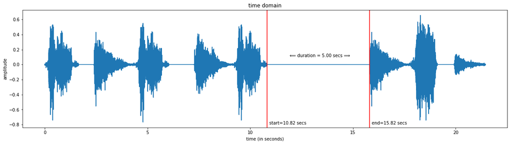

[interactive chart not shown]

Identifying apnoea pauses just using the duration of the pauses in breathing is over-simplistic at best. Pauses in breathing are its main characteristic, but sleep apnoeas are a complex phenomena indeed. There are different types and they may be different from individual to individual. For this reason, a system that can accurately identify apnoeas would need to take into account not just the pauses in breathing but also extract useful information from the breathing sounds and changes in the breathing pattern.

### Definitions

#### Breathing Pause

A **Breathing Pause** represents the abscense of breathing sounds. For practical reasons, we can define a **Breathing Pause** in an arbitrary large acoustic signal as a finite segment of such acoustic signal where the signal's **magnitude** or **amplitude** is always **close enough** to zero.

> **OBS**: *In reality, the breathing sounds would be mixed with background noises and other sounds produced by the body (like heart related sounds).*

#### Breathing Pause Duration

The **Breathing Pause Duration** is the total duration, in units of time (seconds or minutes), of the *Breathing Pause*.

#### Normal and Apnoea Pauses

During breathing we can observe **small and frequent** breathing pauses that are considered **normal pauses**. On the other side, those pauses which have **significantly larger duration** are considered **apnoea pauses** and they're **rare** in comparison with the normal pauses.

## The Problem

As mentioned at the beginning of the document, your main goal is to design an implement a software system that is able to accurately (within reason) identify apnoea pauses.

Apart from the primary goal, there are other concerns the system would need to address too:

- it should be simple to understand
- it should be able to analyse arbitrary large files ($\sim$10 hours) within a reasonable time frame
- it should scale easily (within reason) for analysing an arbitrary large set of audio files simultaneusly

### Tasks

In order to complete this test you are asked to perform following tasks in this (suggested) order:

1. Implement an algoritm for extracting **Breathing Pauses** from audio files using your programming language of choice and following best practices in software engineering to the best of your abilities.
2. Propose, and potentially implement, one or more classification rules for segregating **Breathing Pauses** into **normal** or **apnoea** pauses.
3. Propose a design for a system's architecture that would scale for an arbitrary large set (order of millions) of audio files
4. Create a final report with your findinds. This report should, at least, contain:
   1. A description of the pause extraction algorithm's behaviour in terms of both temporal and spacial [complexity](https://en.wikipedia.org/wiki/Analysis_of_algorithms).
   2. A description of the classification rules accompanied with a reasoned explanation as of why you think they may work.
   3. A high level design of a scalable solution for analysing millions of audio files in a timely fashion accompanied with a reasoned explanation as of why you designed in such a way.
   4. Description of the practical limitations of the proposed solutions, if any.
   5. Future work (i.e: what would you like to have implemented if you had more time, what would be required for a production ready solution, ...)

> **IMPORTANT**: *Please always justify your decisions and assumptions with reasoned explanations when appropriate*

### Rules of the Game

- Use any available technology, but provide reasoned explanations as to why you've chosen them.
- Implement your solution following guidelines mentioned in Program Interface section
- Optionally provide a [Dockerfile](http://docker.com) with your project if it requires a complex setup, or provide a detailed description on how to build and execute your program (providing concrete examples).
- **°°°·.°·..·°¯°·.*.· Have Fun! ·.*.·°¯°·.·° .·°°°**

### Test Audio Files

Actual recordings from individuals may last typically several hours, usually from 6 to 10 hours long, and the signal is encoded at 44.1Khz 16 bits [PCM](https://en.wikipedia.org/wiki/Pulse-code_modulation) mono and stored in files using WAV fomat.

A couple of small audio recordings are provided (using above audio encoding) but the solution should work for arbitrary large audio files in a timely fashion. Locate them in the `examples` folder.

#### Program Interface

Your solution should, at least, provide a command line interface accepting, as arguments, two file paths. For example:

```
$ pause-extractor audiofiles.in.csv results.out.csv
```

... where:

- both argument are [CSV files](https://en.wikipedia.org/wiki/Comma-separated_values)
- the first argument (input file) contains only one column with the file paths to the actual audio files
- the second argument (output file) is the file where the program is going to store the results. This file contains five columns:
  1. `File Path`: as in the input file
  2. `Pause #`: pause number. It's a sequence asigned to each pause detected in the order they appear in the audio file.
  3. `start`: it's the index, masured in seconds from the start of the audio recording, to the beginning of the pause.
  4. `end`: it's the index, masured in seconds from the start of the audio recording, to the end of the pause.
  5. `duration`: it's the pause duration in seconds.
  6. `type`: [optional] the type of pause, `normal` or `apnoea`.

> **OBS**: *fill in the `type` column only if you have implemented a classification rule. Ignore this column otherwise.*

For example:

| audiofiles.in.csv |  | \| |  | results.out.csv |  |  |  |  |
| --- | --- | --- | --- | --- | --- | --- | --- | --- |
| `File Path` |  | \| |  | `File Path` | `Pause #` | `start [secs]` | `end [secs]` | `duration [secs]` |
| /test/audio-A.wav |  | \| |  | /test/audio-A.wav | 1 | 2.03002267574 | 3.04891156463 | 1.01888888889 |
| /test/audio-B.wav |  | \| |  | /test/audio-A.wav | 2 | 6.33866213152 | 7.48360544218 | 1.14494331066 |
| /test/audio-C.wav |  | \| |  | /test/audio-A.wav | 3 | 11.0385714286 | 12.2633786848 | 1.22480725624 |
| ... |  | \| |  | /test/audio-B.wav | 1 | 14.0829478458 | 14.1031746032 | 0.02022675736 |
| ... |  | \| |  | /test/audio-B.wav | 2 | 14.1437641723 | 14.1541043084 | 0.01034013605 |
| ... |  | \| |  | /test/audio-C.wav | 1 | 2.03002267574 | 3.04891156463 | 1.01888888889 |
| ... |  | \| |  | ... | ... | ... | ... | ... |

## Evaluation

You gain points by:

- completing all required tasks.
- writing down your thoughts simply, elegantly and unamabiguously.
- modeling the problem as rigurously or formally (as in mathematical formalism) to the best of your abilities.
- goin above and beyond of what's being asked, but keeping it relevant to the problem in hand.
- asking (the right) questions to the interviewer.

You may lose points by:

- being careless
- making desicions and/or assumptions without reasoned explanations

## Contacts

If in doubt or stuck, feel free to contact us by email or [Slack](https://acurable-recruitment.slack.com/messages/C85UR9Q3Y/) (request and invitation and post your questions on the `#engineering-test` channel)